# ppol563_pset1_wolfe

Abby Wolfe

10/19/2022

#### 1) This database is not a complete representation of all power plants. In fact, it only covers about 30% of all Solar energy produced worldwide. Please write a brief paragraph you would include in an email to colleagues describing the scope and source of the limitations of this data.

While this database is comprehensive for power plants that run on nuclear, geothermal, coal, hydro, biomass, and natural oil/gas energy sources, there are discrepancies in the availability of data on power plants that run primarily on solar and wind power. Most countries do not publicly report on their power sectors and those that do often under-report wind and solar plants because they tend to be newer and smaller than conventional power plants. This situation is a product of limitations regarding this dataset including data availability and reliability, reporting delays, and a lack of operational data reported. So, when looking at the following graphics, it is important to note that renewable energy plants tend to be underrepresented compared to their estimated counts and that there is less data available about how much electricity they generate compared to fossil fuel power plants.

#### 2) Reproduce the histogram plot below, in which we are visualizing commissioning_year with a bin width of 10. Please insert a meaningful title and subtitle.

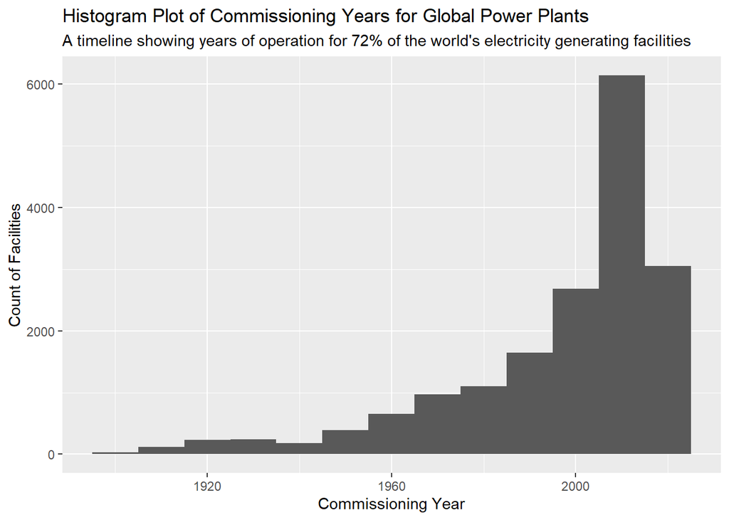

```r
ggplot(data = d1,
       aes(x = commissioning_year)) +
  geom_histogram(binwidth=10) +
  labs(x="Commissioning Year", y="Count of Facilities", title="Histogram Plot of Commissioning Years for Global Power Plants", subtitle="A timeline showing years of operation for 72% of the world's electricity generating facilities")
```

#### 3) Reproduce the boxplot below, in which we are visualizing capacity_mw, grouped by primary_fuel (which is sorted by the median of capacity_mw). Take note of the logged X axis, and please insert a meaningful title and subtitle.

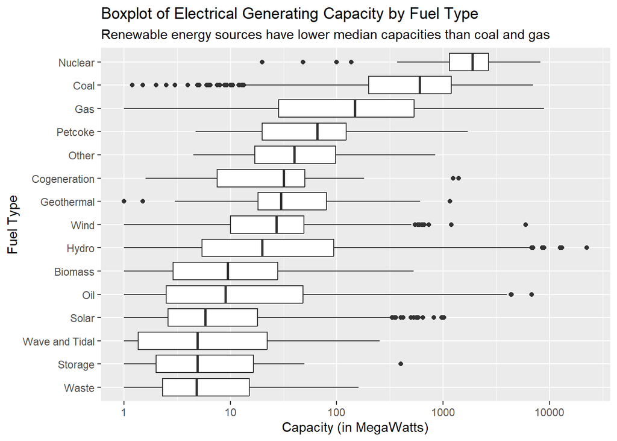

```r
ggplot(data = d1,
       aes(x=reorder(primary_fuel, capacity_mw, FUN=median), y=capacity_mw)) +
  geom_boxplot() +
  scale_y_log10() +
  coord_flip() +
  labs(x="Fuel Type", y="Capacity (in MegaWatts)", title="Boxplot of Electrical Generating Capacity by Fuel Type", subtitle="Renewable energy sources have lower median capacities than coal and gas")
```

#### 4) Reproduce the barchart below, visualizing primary_fuel and colored by renewable. Please insert a meaningful title and subtitle.

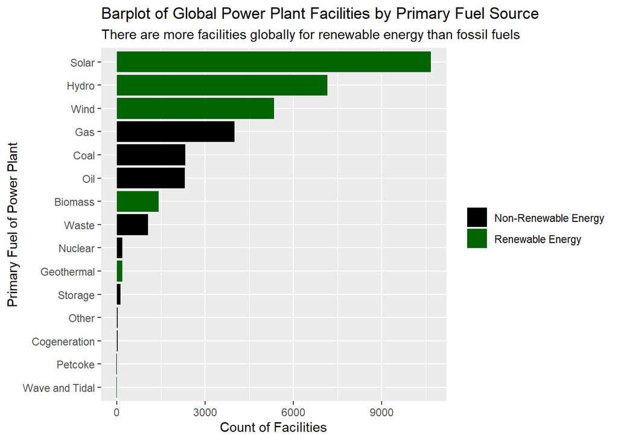

```r
d1 %>%
  group_by(primary_fuel) %>%
  mutate(count = n()) %>%
  ggplot(aes(x=reorder(primary_fuel, count), fill=renewable)) +
  geom_bar(stat='count') +
  coord_flip() +
  scale_fill_manual(values = c('black', 'darkgreen'), name=NULL) +
  labs(x="Primary Fuel of Power Plant", y="Count of Facilities", title="Barplot of Global Power Plant Facilities by Primary Fuel Source", subtitle="There are more facilities globally for renewable energy than fossil fuels")
```

#### 5) Reproduce the grouped barchart below, visualizing counts of the number of facilities in each continent, colored by the renewable variable. Notice the location of the text labels on each bar - this is tricky to do, so you may have to do some googling. Inserting your own meaningful title and subtitle.

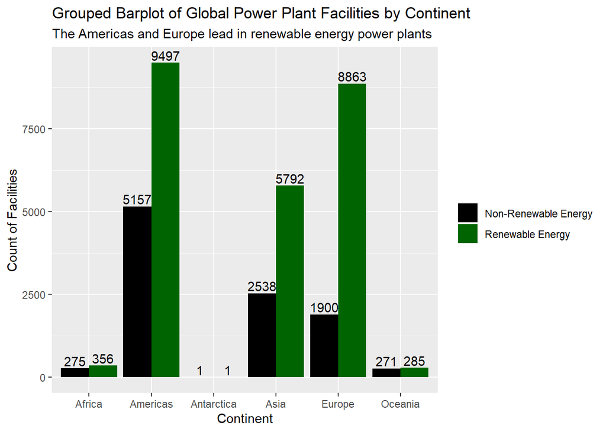

```r
ggplot(d1, aes(x=continent, fill=renewable)) +
  geom_bar(position='dodge', stat='count') +
  scale_fill_manual(values = c('black', 'darkgreen'), name=NULL) +
  geom_text(aes(label = ..count..), stat = "count", position=position_dodge(width=0.9), vjust=-0.25, colour = "black") +
  labs(x="Continent", y="Count of Facilities", title="Grouped Barplot of Global Power Plant Facilities by Continent", subtitle="The Americas and Europe lead in renewable energy power plants")
```

#### 6) Reproduce the 100% stacked barchart below. This is a visualiation of a count of facilities by continent grouped by the renewable variable, and then computed as proportions. Take note of the text labels, which are: